# Cyclistic Capstone Project

Jared

2023-03-20

## Scenario

I am a junior data analyst working in the marketing analysis team at Cyclistic, a fictional bike-share company based in Chicago. From the insights I gather, I will design a new marketing strategy to convert casual riders to members. But first, Cyclistic executives must approve my recommendations, so they must be backed up with compelling data insights and professional data visualizations.

- My Stakeholders are:
  1. Lily Moreno: The Director of Marketing
  2. The Cyclistic Executive Team

### The Ask Phase

1. How do casual riders and annual members use Cylistic differently?
2. Why would casual riders buy Clyclistic annual memberships?
3. How can Cyclistic use digital media to influence casual riders to become members?

### The Prepare Phase

Data Source: 6 Months of data from July 1st, 2022 through December 31st, 2022. Located in .csv files I downloaded from Google’s Data Analytics course on Coursera.

### Process phase

I chose to use R Studio to process, clean, and analyze my data because it contains ~3,000,000 rows of data, which is too much for speadsheet programs to use.

### Analyze phase

#### I ran this query in R Studio:

#### Setting libraries

```r
library(lubridate)
library(tidyverse)
library(janitor)
```

```r
library(dplyr)
library(tidyr)
library(readr)
library(ggplot2)
```

#### Reading the csv files

```r
jul_22 <- read.csv("C:/Users/jared/Desktop/2022 Bikeshare Dataset/202207-divvy-tripdata/202207-divvy-tripdata.csv")
aug_22 <- read.csv("C:/Users/jared/Desktop/2022 Bikeshare Dataset/202208-divvy-tripdata/202208-divvy-tripdata.csv")
sep_22 <- read.csv("C:/Users/jared/Desktop/2022 Bikeshare Dataset/202209-divvy-tripdata/202209-divvy-publictripdata.csv")
oct_22 <- read.csv("C:/Users/jared/Desktop/2022 Bikeshare Dataset/202210-divvy-tripdata/202210-divvy-tripdata.csv")
nov_22 <- read.csv("C:/Users/jared/Desktop/2022 Bikeshare Dataset/202211-divvy-tripdata/202211-divvy-tripdata.csv")
dec_22 <- read.csv("C:/Users/jared/Desktop/2022 Bikeshare Dataset/202212-divvy-tripdata/202212-divvy-tripdata.csv")
```

#### Combining the csv files into one dataframe

```r
combined_df <- rbind(jul_22, aug_22, sep_22, oct_22, nov_22, dec_22)
```

#### Cleaning the data

```r
data <- clean_names(combined_df)
data2 <- remove_empty(data, which = c("rows","cols"), quiet = FALSE)
```

```
## No empty rows to remove.
```

```
## No empty columns to remove.
```

```r
data3 <- distinct(data2)
data4 <- na.omit(data3)
data5 <- data4 %>% separate(started_at, into = c('start_date', 'start_time'), sep = ' ')
data6 <- data5 %>% separate(ended_at, into = c('end_date', 'end_time'), sep = ' ')
data7 <- data6 %>% mutate(start_time = as.POSIXct(start_time, format = "%H:%M:%S"), end_time = as.POSIXct(end_time, format = "%H:%M:%S"))
data8 <- data7 %>% mutate(duration = end_time - start_time)
data9 <- data8 %>% separate(start_time, into = c('del', 'start_time'), sep = ' ')
data10 <- data9 %>% separate(end_time, into = c('del2', 'end_time'), sep = ' ')
data11 <- data10 %>% select(-del)
data12 <- data11 %>% select(-del2)
data13 <- rename(data12, trip_duration = duration)

head(data13)
```

```
##            ride_id rideable_type start_date start_time   end_date end_time
## 1 954144C2F67B1932  classic_bike 2022-07-05   08:12:47 2022-07-05 08:24:32
## 2 292E027607D218B6  classic_bike 2022-07-26   12:53:38 2022-07-26 12:55:31
## 3 57765852588AD6E0  classic_bike 2022-07-03   13:58:49 2022-07-03 14:06:32
## 4 B5B6BE44314590E6  classic_bike 2022-07-31   17:44:21 2022-07-31 18:42:50
## 5 A4C331F2A00E79E0  classic_bike 2022-07-13   19:49:06 2022-07-13 20:15:24
## 6 579D73BE2ED880B3 electric_bike 2022-07-01   17:04:35 2022-07-01 17:13:18
##            start_station_name start_station_id               end_station_name
## 1  Ashland Ave & Blackhawk St            13224       Kingsbury St & Kinzie St
## 2  Buckingham Fountain (Temp)            15541          Michigan Ave & 8th St
## 3  Buckingham Fountain (Temp)            15541          Michigan Ave & 8th St
## 4  Buckingham Fountain (Temp)            15541         Woodlawn Ave & 55th St
## 5      Wabash Ave & Grand Ave     TA1307000117 Sheffield Ave & Wellington Ave
## 6 Desplaines St & Randolph St            15535      Clinton St & Roosevelt Rd
##   end_station_id start_lat start_lng  end_lat   end_lng member_casual
## 1   KA1503000043  41.90707 -87.66725 41.88918 -87.63851        member
## 2            623  41.86962 -87.62398 41.87277 -87.62398        casual
## 3            623  41.86962 -87.62398 41.87277 -87.62398        casual
## 4   TA1307000164  41.86962 -87.62398 41.79526 -87.59647        casual
## 5   TA1307000052  41.89147 -87.62676 41.93625 -87.65266        member
## 6         WL-008  41.88461 -87.64456 41.86712 -87.64109        member
##   trip_duration
## 1      705 secs
## 2      113 secs
## 3      463 secs
## 4     3509 secs
## 5     1578 secs
## 6      523 secs
```

#### Analyzing the data

```r
data18 <- data13[!(data13$trip_duration <= 10),]

data19 <- distinct(data18)
```

```r
data19$date <- as.Date(data19$start_date)
data19$month <- format(as.Date(data19$date), "%m")

trip_duration_mean <- mean(data18$trip_duration)
```

#### Filtering by member/casual

```r
mem_data <- filter(data19, member_casual == "member")
cas_data <- filter(data19, member_casual == "casual")
```

```r
mean(mem_data$trip_duration)
```

```
## Time difference of 732.5044 secs
```

```r
mean(cas_data$trip_duration)
```

```
## Time difference of 1189.772 secs
```

#### Sorting

```r
geo_mem_df <- select(mem_data, "start_station_name", "end_station_name", "start_lat", "start_lng", "end_lat", "end_lng")
geo_cas_df <- select(cas_data, "start_station_name", "end_station_name", "start_lat", "start_lng", "end_lat", "end_lng")
```

```r
mem_cas_only <- select(data19, "member_casual")
mem_cas_only2 <- na.omit(mem_cas_only)
```

```r
data20 <- na.omit(data19)
```

#### Graphing

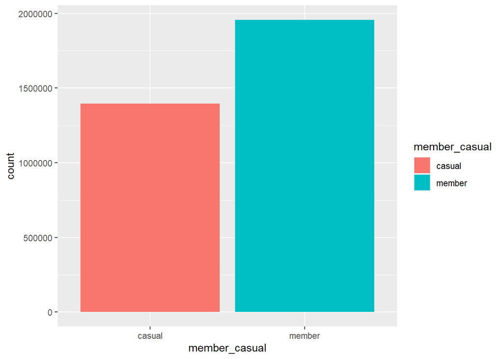

```r
mem_cas_barchart <- ggplot(data=mem_cas_only2, aes(x=member_casual)) + geom_bar(stat = "count", aes(fill=member_casual))
mem_cas_barchart
```

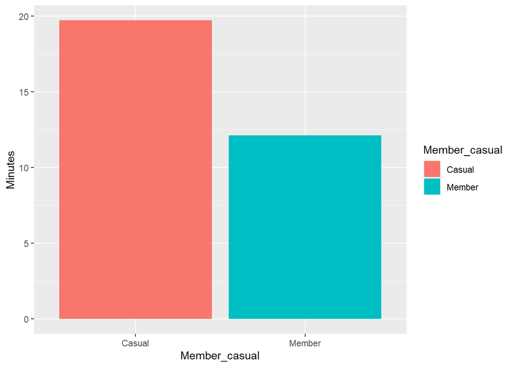

```r
ggsave("mem_cas_barchart.png")
dftrip <- data.frame(Member_casual=c("Member", "Casual"), Minutes=c(12.13, 19.73) )

trip_duration_barchart <- ggplot(data=dftrip, aes(x=Member_casual, y=Minutes)) + geom_bar(stat = "identity", aes(fill=Member_casual))
trip_duration_barchart
```

```r
ggsave("trip_duration_barchart.png")
data20$month <- format(as.Date(data19$date), "%m")
data20$month <- as.numeric(data19$month)
```

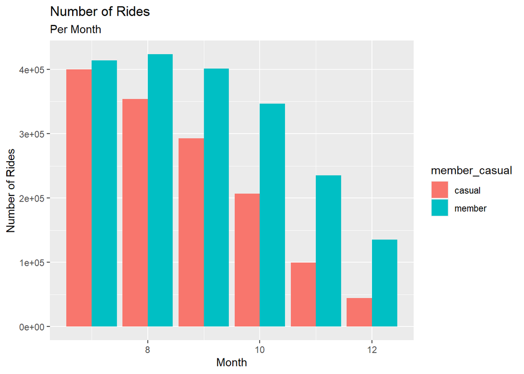

```r
data20%>% group_by(month, member_casual) %>% summarise(number_of_rides = n()) %>% ggplot() + geom_bar(position="dodge", stat = "identity", aes(x=month, y=number_of_rides, fill=member_casual)) + labs(title = "Number of Rides", subtitle = "Per Month") + xlab("Month") + ylab("Number of Rides")
```

```r
ggsave("rides_per_month.png")
```

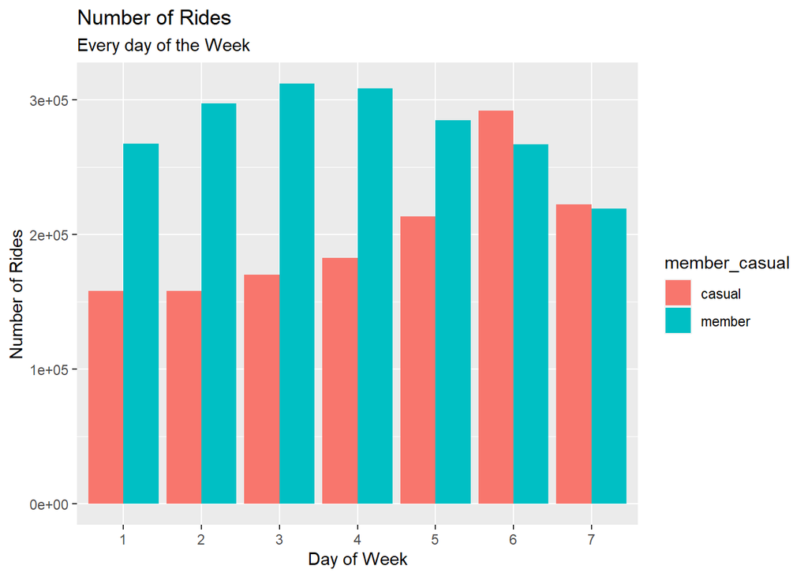

```r
data20$day_of_week <- format(as.Date(data19$date), "%u")

data20%>% group_by(day_of_week, member_casual) %>% summarise(number_of_rides = n()) %>% ggplot() + geom_bar(position="dodge", stat = "identity", aes(x=day_of_week, y=number_of_rides, fill=member_casual)) + labs(title = "Number of Rides", subtitle = "Every day of the Week") + xlab("Day of Week") + ylab("Number of Rides")
```

```r
ggsave("rides_per_day.png")
```

## Findings

Let’s answer the first question of the Ask Phase: “How do casual riders and annual members use Cylistic differently?”

First, we should look at how many rides there were in this dataset:

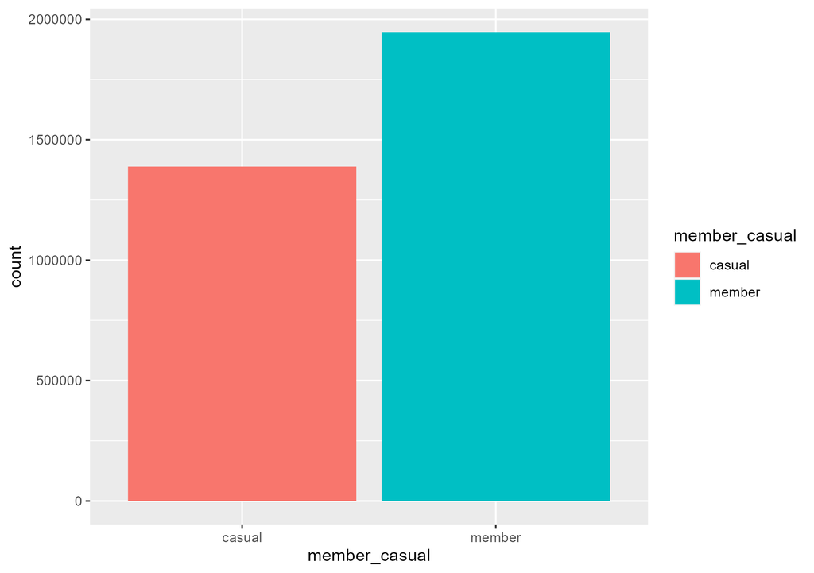

There were more total rides by members than casuals in the past 6 months .

Now let’s take a look at the average trip duration:

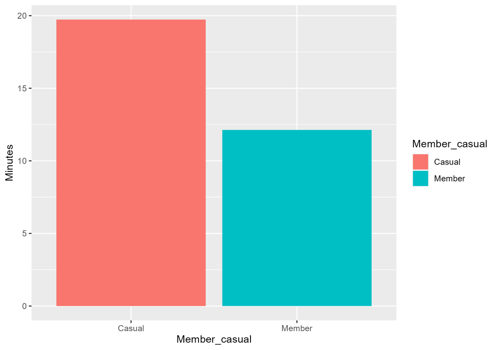

As you can see in this bar graph, casual riders on average take more time on their rides than members.

Next, We’ll look at at the number if rides by day of the week:

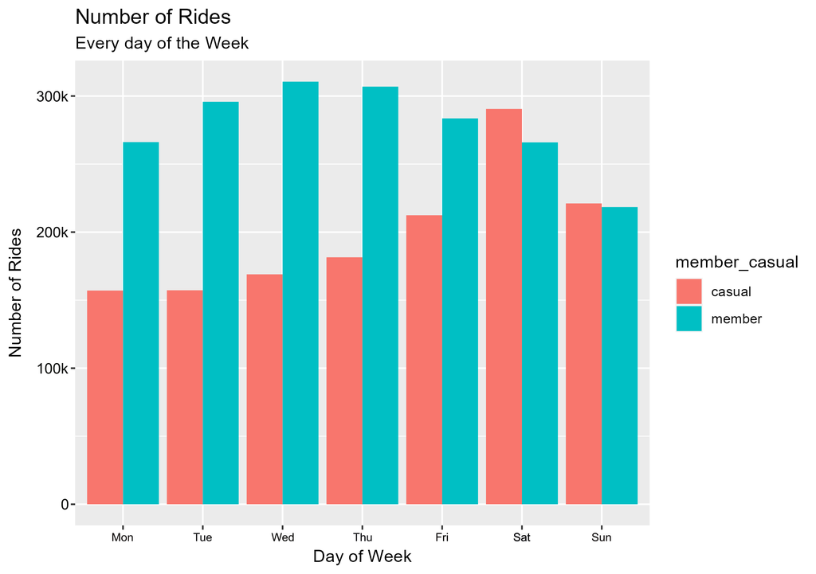

What we can see here is casual riders use Cyclistic more often on the weekends while members actually peak in the middle of the week and take a slight dip on the weekends.

Now let’s see what the monthly data says:

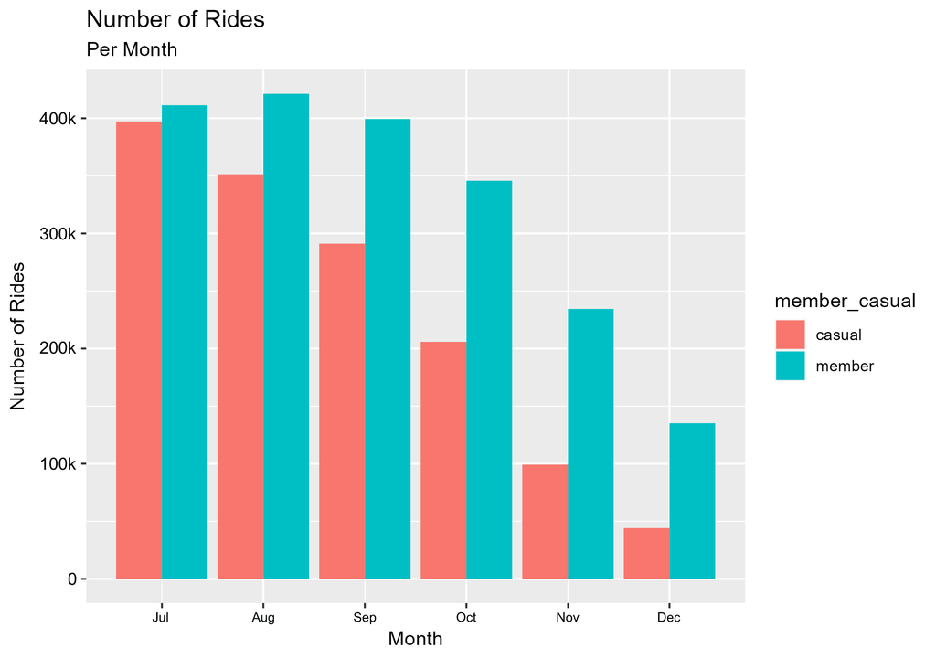

Looks like the warmer the month, the more total rides we have. The fall off here is more extreme for casuals than annual members.

Finally, we should look at some geographical data:

#### Casual

[figure not shown]

#### Member

[figure not shown]

What I notice here is that casual riders like to ride along the coast of Lake Michigan, where there are parks and sight seeing locations. Members are a little more spread out and in the middle of the city where there are more office buildings and businesses.

### Answering our three questions

So, to answer our first question: “How to casual riders and annual members use Cyclistic differently?”

I can conclude that casual riders use Cylistic for recreation on their own free time, while annual members use Cyclistic for more vocational reasons.

As a result of this, I think adding a seasonal or monthly subscription would convert a lot of casual riders into members, Which brings us to our second question: “Why would casual riders buy Clyclistic annual memberships?”. I believe casual Cyclistic riders would purchase a seasonal or monthly subscription because they mainly ride in warmer months and on weekends for their own personal enjoyment.

Now we have to answer our third question: “How can Cyclistic use digital media to influence casual riders to become members?”. I believe Cylistic can use localized advertisements on social media to promote the new seasonal/monthly subscription. This will get casual riders and new customers excited about riding Cyclistic.